# Lab_3_OLEA

Author

Julian Olea

```r
setwd("~/Masters/PM_566/labs/Lab_03")
```

```r
# library(readr)
library(dplyr)
library(tidyr)
library(ggplot2)
library(rstatix)
library(ggpubr)
library(leaflet)
library(lubridate)
```

# 1: Read the data

```r
# met <- read_csv("met_all.gz")

met <- read.table("met_all.gz", header = TRUE, sep = ",")
```

# 2: Check the dimensions, headers, footers

```r
dim(met)
```

```
[1] 2377343      30
```

```r
head(met, 3)
```

```
  USAFID  WBAN year month day hour min  lat      lon elev wind.dir wind.dir.qc
1 690150 93121 2019     8   1    0  56 34.3 -116.166  696      220           5
2 690150 93121 2019     8   1    1  56 34.3 -116.166  696      230           5
3 690150 93121 2019     8   1    2  56 34.3 -116.166  696      230           5
  wind.type.code wind.sp wind.sp.qc ceiling.ht ceiling.ht.qc ceiling.ht.method
1              N     5.7          5      22000             5                 9
2              N     8.2          5      22000             5                 9
3              N     6.7          5      22000             5                 9
  sky.cond vis.dist vis.dist.qc vis.var vis.var.qc temp temp.qc dew.point
1        N    16093           5       N          5 37.2       5      10.6
2        N    16093           5       N          5 35.6       5      10.6
3        N    16093           5       N          5 34.4       5       7.2
  dew.point.qc atm.press atm.press.qc       rh
1            5    1009.9            5 19.88127
2            5    1010.3            5 21.76098
3            5    1010.6            5 18.48212
```

```r
tail(met, 3)
```

```
        USAFID  WBAN year month day hour min    lat      lon elev wind.dir
2377341 726813 94195 2019     8  31   21  56 43.650 -116.633  741       10
2377342 726813 94195 2019     8  31   22  56 43.642 -116.636  741       10
2377343 726813 94195 2019     8  31   23  56 43.642 -116.636  741       40
        wind.dir.qc wind.type.code wind.sp wind.sp.qc ceiling.ht ceiling.ht.qc
2377341           5              N     2.6          5      22000             5
2377342           1              N     2.1          1      22000             1
2377343           1              N     2.1          1      22000             1
        ceiling.ht.method sky.cond vis.dist vis.dist.qc vis.var vis.var.qc temp
2377341                 9        N    14484           5       N          5 35.0
2377342                 9        N    16093           1       9          9 34.4
2377343                 9        N    16093           1       9          9 34.4
        temp.qc dew.point dew.point.qc atm.press atm.press.qc       rh
2377341       5       9.4            5    1010.8            5 20.76325
2377342       1       9.4            1    1010.1            1 21.48631
2377343       1       9.4            1    1009.6            1 21.48631
```

There are 2377343 and 30 columns

# 4:Take a closer look at the key variables.

```r
table(met$year)
```

```
   2019
2377343
```

```r
table(met$day)
```

```
    1     2     3     4     5     6     7     8     9    10    11    12    13
75975 75923 76915 76594 76332 76734 77677 77766 75366 75450 76187 75052 76906
   14    15    16    17    18    19    20    21    22    23    24    25    26
77852 76217 78015 78219 79191 76709 75527 75786 78312 77413 76965 76806 79114
   27    28    29    30    31
79789 77059 71712 74931 74849
```

```r
table(met$hour)
```

```
     0      1      2      3      4      5      6      7      8      9     10
 99434  93482  93770  96703 110504 112128 106235 101985 100310 102915 101880
    11     12     13     14     15     16     17     18     19     20     21
100470 103605  97004  96507  97635  94942  94184 100179  94604  94928  96070
    22     23
 94046  93823
```

```r
summary(met$temp)
```

```
   Min. 1st Qu.  Median    Mean 3rd Qu.    Max.    NA's
 -40.00   19.60   23.50   23.59   27.80   56.00   60089
```

```r
summary(met$elev)
```

```
   Min. 1st Qu.  Median    Mean 3rd Qu.    Max.
  -13.0   101.0   252.0   415.8   400.0  9999.0
```

```r
summary(met$wind.sp)
```

```
   Min. 1st Qu.  Median    Mean 3rd Qu.    Max.    NA's
   0.00    0.00    2.10    2.46    3.60   36.00   79693
```

```r
# met[met$elev == 9999.0 , ] <- NA

met %>% filter(!elev == 9999.0) -> met_filtered

summary(met_filtered$elev)
```

```
   Min. 1st Qu.  Median    Mean 3rd Qu.    Max.
    -13     101     252     413     400    4113
```

After subsetting the data to exclude the sites at the 9999 meter elevation, the new max site elevation is 4113 meters.

```r
met_filtered %>% filter(temp > -40) %>% select(temp) %>% summary()
```

```
      temp
 Min.   :-17.20
 1st Qu.: 19.60
 Median : 23.50
 Mean   : 23.59
 3rd Qu.: 27.80
 Max.   : 56.00
```

The minimum temperature reported is -17.20 celsius, we will check if this makes sense.

# 5: Check the data against an external data source.

```r
met_filtered %>% arrange(temp) %>% select(temp, lat, lon, elev) %>% distinct() %>% head(3)
```

```
   temp    lat      lon elev
1 -40.0 29.117  -89.550   36
2 -17.2 38.767 -104.300 1838
3 -17.0 27.901  -98.052   78
```

```r
met_filtered %>% filter(temp > -15) %>% select(temp, elev) %>% summary()
```

```
      temp            elev
 Min.   :-3.00   Min.   : -13.0
 1st Qu.:19.60   1st Qu.: 101.0
 Median :23.50   Median : 252.0
 Mean   :23.59   Mean   : 414.3
 3rd Qu.:27.80   3rd Qu.: 400.0
 Max.   :56.00   Max.   :4113.0
```

```r
met_filtered %>% filter(temp > -15) -> met_filtered
```

# 6: Calculate summary statistics

```r
met_filtered %>% arrange(desc(elev)) %>% head(3)
```

```
  USAFID WBAN year month day hour min  lat      lon elev wind.dir wind.dir.qc
1 720385  419 2019     8   1    0  36 39.8 -105.766 4113      170           5
2 720385  419 2019     8   1    0  54 39.8 -105.766 4113      100           5
3 720385  419 2019     8   1    1  12 39.8 -105.766 4113       90           5
  wind.type.code wind.sp wind.sp.qc ceiling.ht ceiling.ht.qc ceiling.ht.method
1              N     8.8          5       1372             5                 M
2              N     2.6          5       1372             5                 M
3              N     3.1          5       1981             5                 M
  sky.cond vis.dist vis.dist.qc vis.var vis.var.qc temp temp.qc dew.point
1        N       NA           9       N          5    9       5         1
2        N       NA           9       N          5    9       5         1
3        N       NA           9       N          5    9       5         2
  dew.point.qc atm.press atm.press.qc       rh
1            5        NA            9 57.61039
2            5        NA            9 57.61039
3            5        NA            9 61.85243
```

```r
# met_filtered %>% filter(elev == 4113.0) -> met_max_elev

met_filtered %>%
  filter(elev == 4113.0) %>%
  summarise(temp_windsp = cor(temp, wind.sp, use = "complete"),
            temp_day = cor(temp, day, use = "complete"),
            temp_hour = cor(temp, hour, use = "complete"),
            windsp_day = cor(wind.sp, day, use = "complete"),
            windsp_hour = cor(wind.sp, hour, use = "complete")
  )
```

```
  temp_windsp     temp_day temp_hour windsp_day windsp_hour
1 -0.09373843 -0.003857766 0.4397261  0.3643079  0.08807315
```

# 7: Exploratory graphs

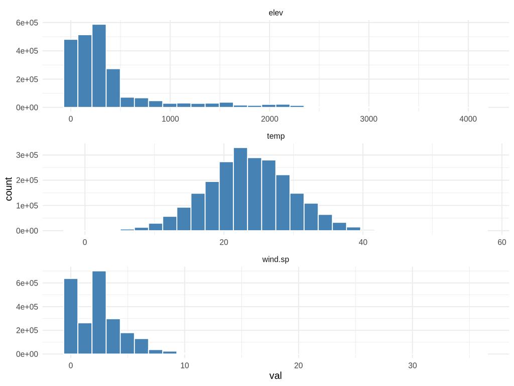

```r
met_filtered %>%
  select(elev, temp, wind.sp) %>%
  pivot_longer(cols = everything(), names_to = "var", values_to = "val") %>%
  ggplot(aes(x = val)) +
  geom_histogram(fill = "steelblue", color = "white") +
  facet_wrap(~ var, scales = "free", ncol = 1) +
  theme_minimal()
```

```r
met_filtered %>%
  filter(elev == 4113.0) %>%
  leaflet() %>%
  addProviderTiles('OpenStreetMap') %>%
  addCircles(lat =~ lat, lng =~ lon, opacity = 1, fillOpacity = 1, radius = 100)
```

[interactive chart not shown]

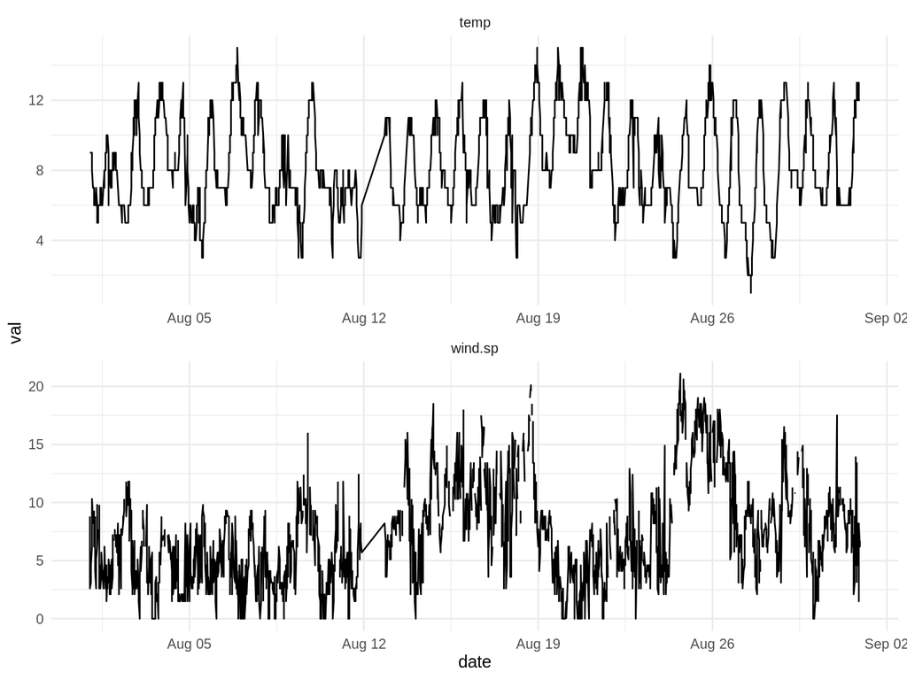

```r
met_filtered %>%
  filter(elev == 4113.0) %>%
  mutate(date = ymd_h(paste(year, month, day, hour, sep = " "))) %>%
  relocate(date, .after = min) %>%
  arrange(date) %>%
  select(date, temp, wind.sp) %>%
  pivot_longer(cols = c(temp, wind.sp), names_to = "var", values_to = "val") %>%
  ggplot(aes(x = date, y = val)) +
  geom_line() +
  facet_wrap(~var, scales = "free", ncol = 1) +
  theme_minimal()
```

Temperature seems to vary without consistency. Wind speed interestingly seems to ramp up later in the month.

# 8: Ask questions

Let’s check out the relationship between temperature and wind speed as the day advances.

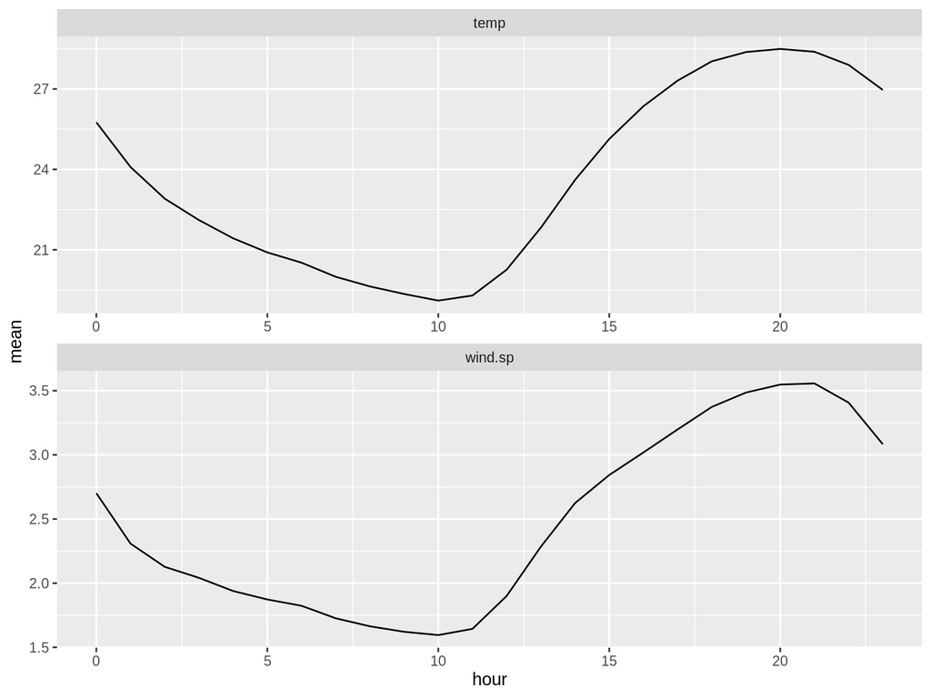

```r
met_filtered %>%
  select(hour, wind.sp, temp) %>%
  tidyr::pivot_longer(cols = -"hour",
                      names_to = "measure",
                      values_to = "value"
  ) %>%
  group_by(hour, measure) %>%
  summarise(
    mean   = mean(value, na.rm = TRUE),
    median = median(value, na.rm = TRUE),
    .groups = "drop"
  ) %>%
  select(hour, measure, mean) %>%

  ggplot(aes(x = hour, y = mean)) +
  geom_line() +
  facet_wrap(~measure, scales = "free", ncol = 1)
```

After grouping all the data by time of day (hour) and taking the average of temperature and wind speed, it seems that both wind speed and temperatrue follow the same trend over the course of 24 hours

Let’s see how well they correlate.

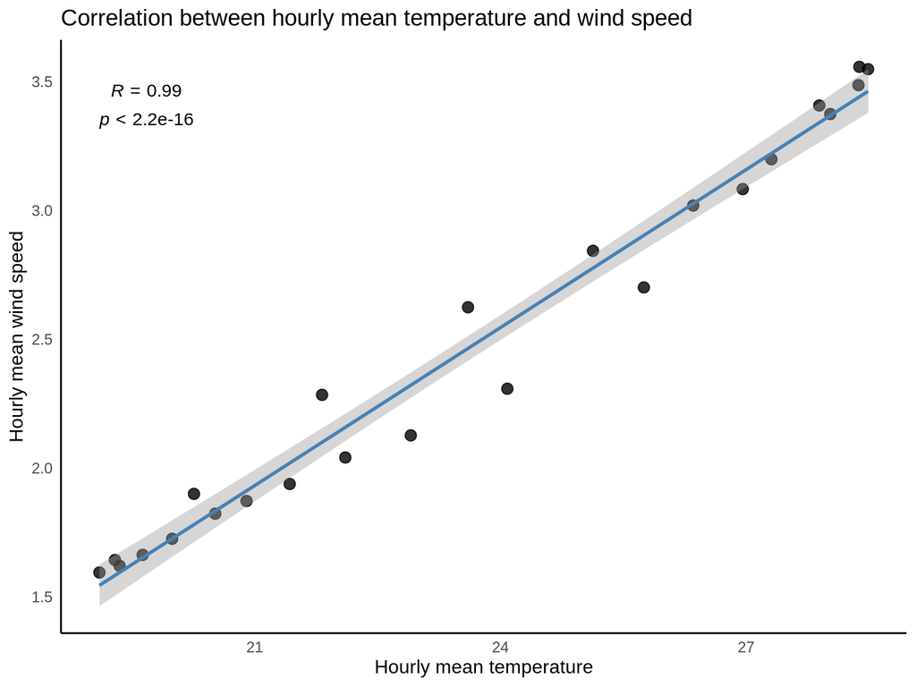

```r
met_filtered %>%
  select(hour, temp, wind.sp) %>%
  group_by(hour) %>%
  summarise(
    mean_temp = mean(temp, na.rm = TRUE),
    mean_wind = mean(wind.sp, na.rm = TRUE),
    .groups = "drop"
  ) %>%
  ggplot(aes(x = mean_temp, y = mean_wind)) +
  geom_point(size = 3, alpha = 0.8) +
  geom_smooth(method = "lm", se = TRUE, color = "steelblue", linewidth = 1) +
  ggpubr::stat_cor(
    method = "pearson",
    label.x.npc = "left",
    label.y.npc = "top",
    parse = FALSE,
    label.sep = "\n",
    size = 4
  ) +
  labs(
    x = "Hourly mean temperature",
    y = "Hourly mean wind speed",
    title = "Correlation between hourly mean temperature and wind speed"
  ) +
  theme_minimal(base_size = 12) +
  theme(
    panel.grid.major = element_blank(),
    panel.grid.minor = element_blank(),
    panel.background = element_blank(),
    axis.line = element_line(colour = "black")
  )
```

The correlation seems *very* strong. Let’s manually examine the data to make sure that makes sense.

```r
met_filtered %>%
  select(hour, temp, wind.sp) %>%
  group_by(hour) %>%
  summarise(
    mean_temp = mean(temp, na.rm = TRUE),
    mean_wind = mean(wind.sp, na.rm = TRUE),
    .groups = "drop"
  )
```

```
# A tibble: 24 × 3
    hour mean_temp mean_wind
   <int>     <dbl>     <dbl>
 1     0      25.8      2.70
 2     1      24.1      2.31
 3     2      22.9      2.13
 4     3      22.1      2.04
 5     4      21.4      1.94
 6     5      20.9      1.87
 7     6      20.5      1.82
 8     7      20.0      1.73
 9     8      19.6      1.66
10     9      19.4      1.62
# ℹ 14 more rows
```

After looking at the mean temperature and mean wind globally by hour, the trend does seem to check out!